# karyotype.rmd

xx

January 8, 2020

## A Simple example

There are 6 balls in the bag, and 2 of them are red. You randomly take out 2 of the balls, what is probobility of getting 1 red ball. let N be the total number of balls, K be the number of red balls, n be the number of balls taken out, and k be the red balls taken out. then, we have
$$P(x = k) = \frac{{N-K \choose n-k}{K \choose k}}{{N \choose n}}$$

But the reverse question is more of our interest. We don’t know the number of red balls in the ball. By taking out a small number of balls and counting the number of red balls within the sample, we can infer how many red ball in the balls with spefified confident level.

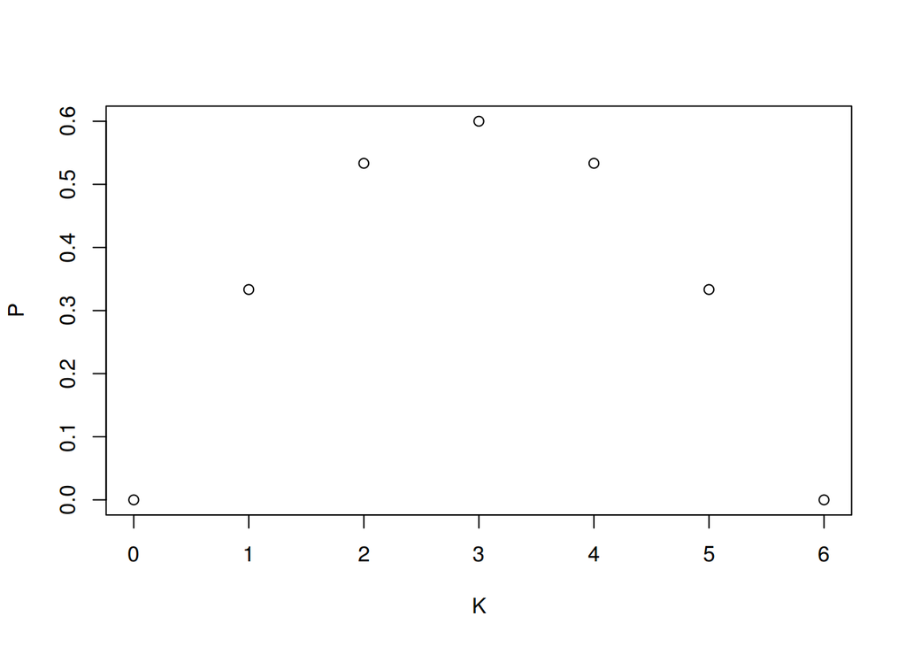

```r
K = seq(0,N)
P = choose(N-K,n-k)*choose(K,k)/choose(N,n)
plot(K,P)
```

## Karyotype Problem

Say we have 1e6 cells, and take 20 of them for analysis. it turns out 2 of them have abnormal chromosome. then how much anormal cells in the population.

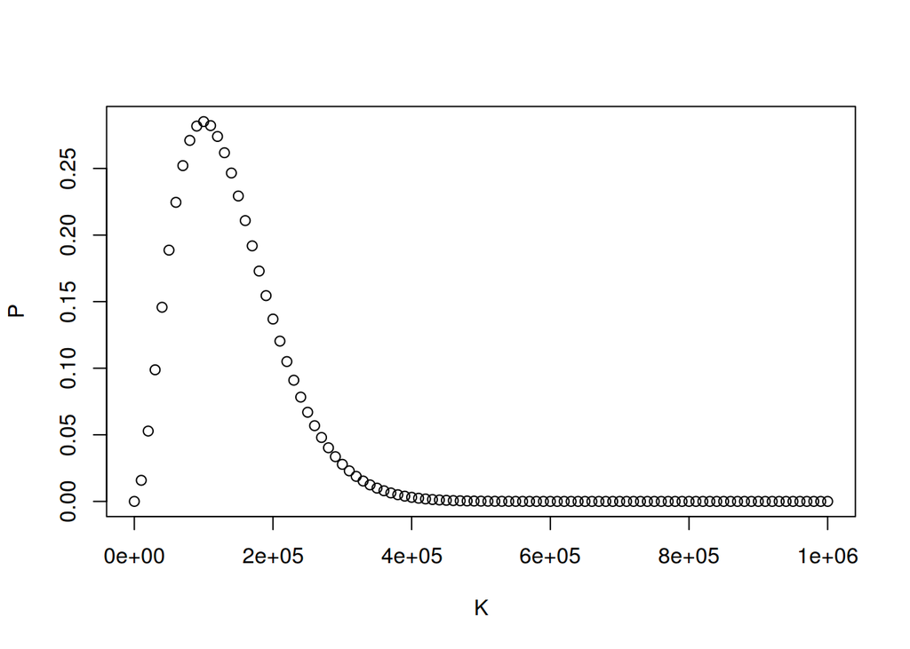

```r
N = 1e6
n = 20
k = 2
K = seq(0,N,N/100)
P = choose(N-K,n-k)*choose(K,k)/choose(N,n)
plot(K,P)
```

```r
f <- function(x) abs(choose(N-x,n-k)*choose(x,k)/choose(N,n) - 0.05)
pk = optimize(f, lower=N*k/n*1.2, upper=N)
pk
```

```
## $minimum
## [1] 267629.1
##
## $objective
## [1] 2.669961e-09
```

so if there are more than 2.676291e+05 abnormal cells, the probobility see such result would be less than 5%.

if we increase the number of analysis cells

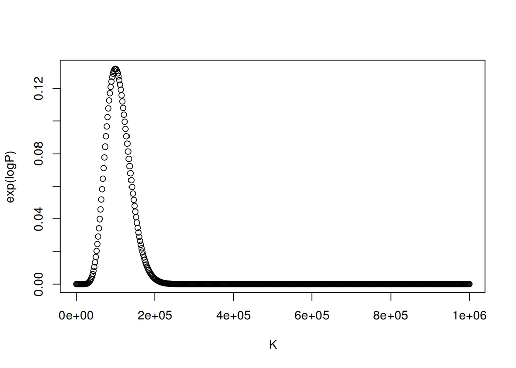

```r
N = 1e6
n = 100
k = 10
K = seq(0,N,N/500)
logP = lchoose(N-K,n-k)+lchoose(K,k)-lchoose(N,n)
plot(K,exp(logP))
```

```r
f <- function(x) abs(lchoose(N-x,n-k)+lchoose(x,k)-lchoose(N,n) - log(0.05) )
pk = optimize(f, lower=N*k/n*1.2, upper=N)
pk
```

```
## $minimum
## [1] 146870.8
##
## $objective
## [1] 2.436302e-08
```

put it to more extreme.

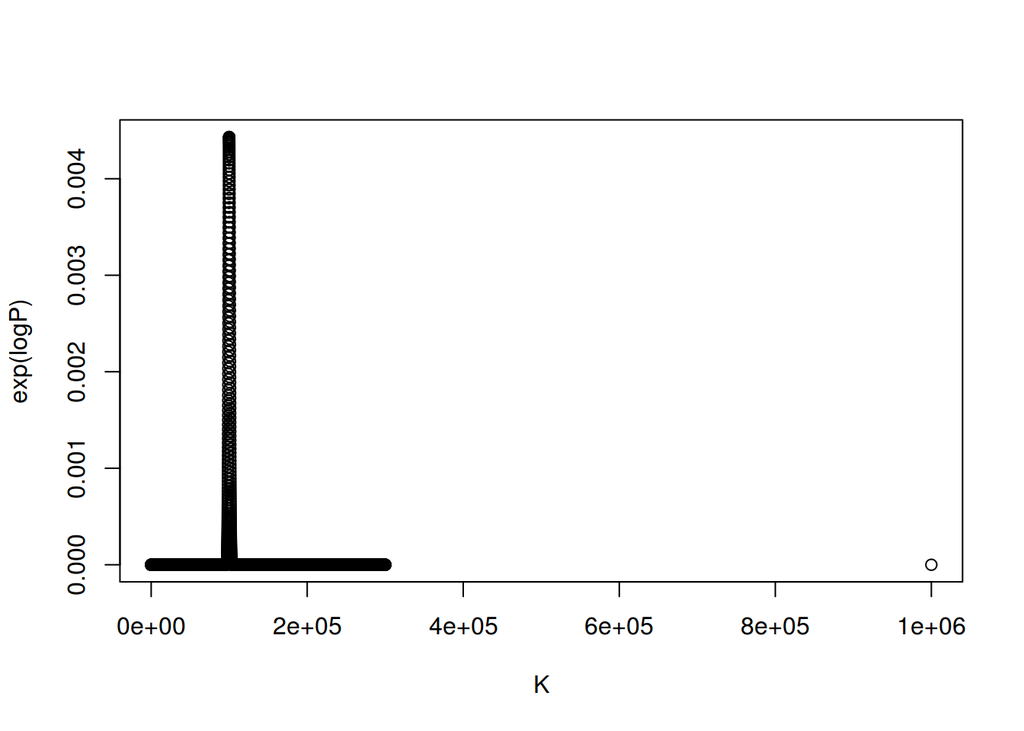

```r
N = 1e6
n = 1e5
k = 1e4
K = seq(0,N*.3,N/50000)
K = c(K,N)
logP = lchoose(N-K,n-k)+lchoose(K,k)-lchoose(N,n)
plot(K,exp(logP))
```

## in the case of k == 0

when there is no abnormal cells in the sample, how confident are we about claiming the population is normal.

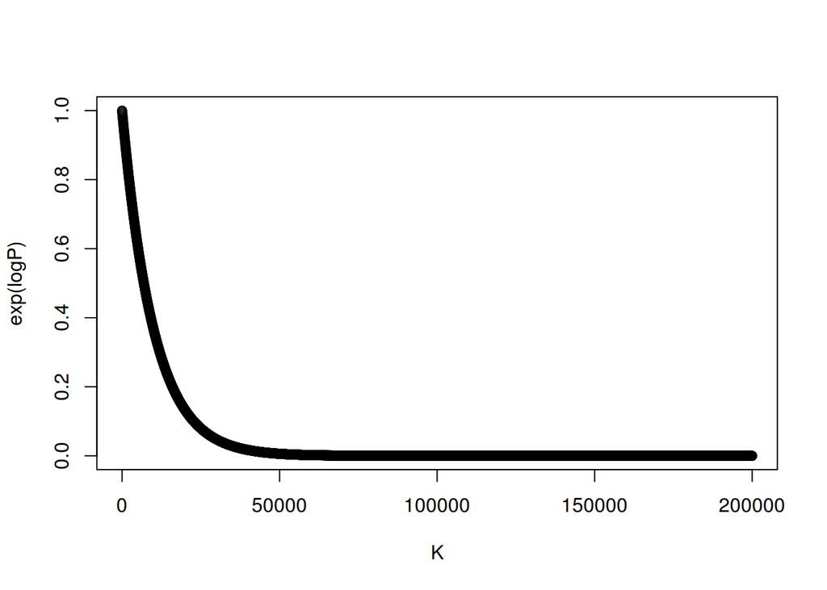

```r
N = 1e6
k = 0
n = 100
K = seq(0,N*.2,N*.2/5000)
logP = lchoose(N-K,n-k)+lchoose(K,k)-lchoose(N,n)
plot(K,exp(logP))
```

```r
f <- function(x) abs(lchoose(N-x,n-k)+lchoose(x,k)-lchoose(N,n) - log(0.05) )
pk = optimize(f, lower=N*k/n*1.2, upper=N*.2)
pk
```

```
## $minimum
## [1] 29511.59
##
## $objective
## [1] 3.816984e-08
```

here, we compare the difference between n = 20,100, etc.

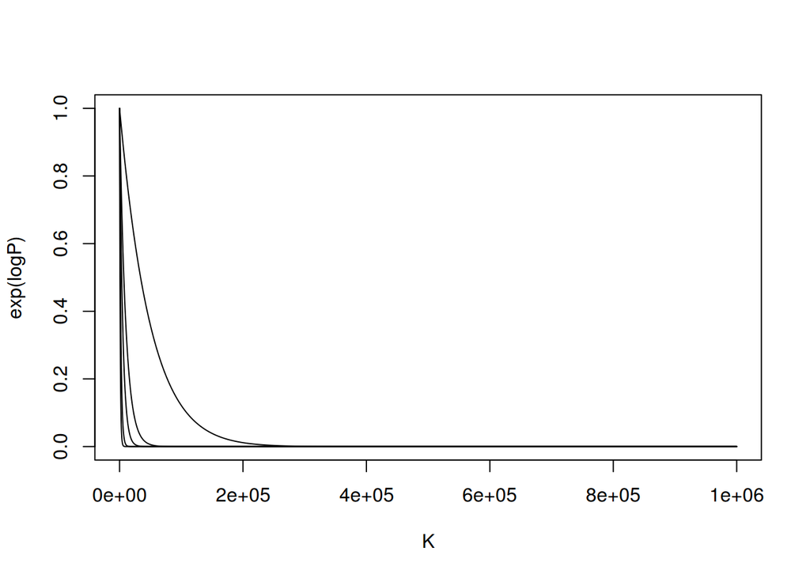

```
## $minimum
## [1] 139107
##
## $objective
## [1] 4.445208e-07
##
## $minimum
## [1] 29511.59
##
## $objective
## [1] 3.816984e-08
##
## $minimum
## [1] 14865.56
##
## $objective
## [1] 2.542078e-08
##
## $minimum
## [1] 5972.046
##
## $objective
## [1] 3.068611e-05
##
## $minimum
## [1] 2989.755
##
## $objective
## [1] 2.365009e-08
```

```r
N = 1e6
k = 0
ns = c(20,100,200,500,1000)
for(n in ns){
K = seq(0,N,N/5000)
logP = lchoose(N-K,n-k)+lchoose(K,k)-lchoose(N,n)
if(n==ns[1]) plot(K,exp(logP),type = 'l')
else points(K,exp(logP),type = 'l')

f <- function(x) abs(lchoose(N-x,n-k)+lchoose(x,k)-lchoose(N,n) - log(0.05) )
pk = optimize(f, lower=N*k/n*1.2, upper=N*.2)
print(pk)
}
```